# Survival Analysis for molecular subtypes of HGG

C. Savonen for ALSF CCDL, Krutika Gaonkar for D3b, Jo Lynne Rokita for D3b

2019, 2022

**Purpose:**

Runs survival analysis models for subtypes of HGG tumors.

## Usage

Uses a wrapper function (`survival_analysis`) from utils folder.

## Setup

#### Packages and functions

Read in set up script.

```r
library(survival)
library(ggpubr)
library(tidyverse)
# This script contains a wrapper function that can conduct the survival analyses
source(file.path("util", "survival_models.R"))
# Magrittr pipe
`%>%` <- dplyr::`%>%`
```

#### Set up files and directories

Set up output directories.

```r
data_dir <- file.path("..", "..", "data")
results_dir <- "results/subtypes"
plots_dir <- "plots"
```

Make output directories.

```r
if (!dir.exists(results_dir)) {
  dir.create(results_dir)
}
if (!dir.exists(plots_dir)) {
  dir.create(plots_dir)
}
```

Declare input file paths and useful variables

```r
metadata_file <- file.path(data_dir, "pbta-histologies.tsv")
independent_primary_file <- file.path(
  data_dir,
  "independent-specimens.wgswxs.primary.tsv")

# Number of participants required to consider a subtype in survival analysis
n_participants <- 3
```

Declare output file paths for HGG/DMG all subtypes.

```r
kap_meier_plot_file <- file.path(plots_dir, "KM_hgg_subtypes.pdf")
kap_meier_model_file <- file.path(results_dir, "logrank_hgg_subtypes.RDS")
```

## Import the metadata

```r
# choose HGG samples
# remove cell-lines from this analysis as well
metadata <- readr::read_tsv(
  metadata_file,
  col_types = readr::cols(
    molecular_subtype = readr::col_character())) %>%
  dplyr::filter(
      broad_histology == "Diffuse astrocytic and oligodendroglial tumor" &
      composition=="Solid Tissue" &
      # remove oligo
      cancer_group != "Oligodendroglioma" &
      # remove samples with no OS data
      !is.na(OS_days) &
      # remove To be classified samples
      !grepl("To be classified", molecular_subtype)) %>%
  mutate(
    OS_years = OS_days / 365.25
  ) %>%
  # keep only relevant columns
  select(Kids_First_Participant_ID, Kids_First_Biospecimen_ID, experimental_strategy, tumor_descriptor, molecular_subtype, OS_days, OS_years, OS_status)
```

#### Using independent_primary if multiple subtypes per patient are found

This way we subset the metadata to 1 single primary sample per patient ID

```r
# Patients with multiple different molecular subtype might affect downstream analysis for survival so using independent_primary sample set which has 1-1 sample-patient matches
independent_primary <- readr::read_tsv(independent_primary_file)
# select only independent primary bs_ids to get overall survival
metadata_ind_dna <- metadata %>%
  dplyr::filter(Kids_First_Biospecimen_ID %in%
                  independent_primary$Kids_First_Biospecimen_ID)

# check whether any RNA samples not in DNA subset
metadata_rna <- metadata %>%
  filter(experimental_strategy == "RNA-Seq" &
           tumor_descriptor == "Initial CNS Tumor" &
           !is.na(OS_years)) %>%
  unique()

# These are the IDs for patients with RNA samples but not DNA, if any
rna_pts_to_add <- setdiff(unique(metadata_rna$Kids_First_Participant_ID), metadata_ind_dna$Kids_First_Participant_ID)
rna_pts_to_add
```

```
character(0)
```

```r
metadata_ind_dna <- metadata_ind_dna %>%
  group_by(molecular_subtype) %>%
  # directly add a column for the counts instead of tallying down into a summarized tibble
  mutate(n_molecular_subtype = n()) %>%
  # keep only sufficient n
  filter(n_molecular_subtype>n_participants) %>%
  # rm the counting column and it's all cleaned up
  select(-n_molecular_subtype) %>%
  ungroup(molecular_subtype)

# Check Ns
as.data.frame(table(metadata_ind_dna$OS_status, metadata_ind_dna$molecular_subtype))
```

| Var1 | Var2 | Freq |
| --- | --- | --- |
| DECEASED | DMG, H3 K28 | 16 |
| LIVING | DMG, H3 K28 | 0 |
| DECEASED | DMG, H3 K28, TP53 activated | 7 |
| LIVING | DMG, H3 K28, TP53 activated | 0 |
| DECEASED | DMG, H3 K28, TP53 loss | 28 |
| LIVING | DMG, H3 K28, TP53 loss | 0 |
| DECEASED | HGG, H3 wildtype | 7 |
| LIVING | HGG, H3 wildtype | 5 |
| DECEASED | HGG, H3 wildtype, TP53 loss | 8 |
| LIVING | HGG, H3 wildtype, TP53 loss | 0 |

## Kaplan-Meier for all HGG/DMG subtypes

The [Kaplan-Meier](https://www.ncbi.nlm.nih.gov/pmc/articles/PMC3059453/) survival curve shows the probability of survival over time.

```r
table(metadata$OS_status)
```

```
DECEASED   LIVING
     240       24
```

```r
kap_fit <- survival_analysis(
  metadata  = metadata_ind_dna,
  ind_var = "molecular_subtype",
  test = "kap.meier",
  metadata_sample_col = "Kids_First_Biospecimen_ID"
  )
```

```
Testing model: survival::Surv(OS_days, OS_status) ~ molecular_subtype with kap.meier
```

```r
# median and 0.95CI survival days
kap_fit
```

```
$model
Call: survfit(formula = survival::Surv(OS_days, OS_status) ~ molecular_subtype,
    data = ind_var_df)

                                               n events median 0.95LCL 0.95UCL
molecular_subtype=DMG, H3 K28                 16     16    400     336     854
molecular_subtype=DMG, H3 K28, TP53 activated  7      7    294      18      NA
molecular_subtype=DMG, H3 K28, TP53 loss      28     28    274     232     392
molecular_subtype=HGG, H3 wildtype            12      7    582     375      NA
molecular_subtype=HGG, H3 wildtype, TP53 loss  8      8    392     349      NA

$table
```

| time | n.risk | n.event | n.censor | estimate | std.error | conf.high | conf.low | strata |
| --- | --- | --- | --- | --- | --- | --- | --- | --- |
| 61 | 16 | 1 | 0 | 0.93750000 | 0.06454972 | 1.0000000 | 0.826088265 | molecular_subtype=DMG, H3 K28 |
| 179 | 15 | 1 | 0 | 0.87500000 | 0.09449112 | 1.0000000 | 0.727071410 | molecular_subtype=DMG, H3 K28 |
| 241 | 14 | 1 | 0 | 0.81250000 | 0.12009612 | 1.0000000 | 0.642092166 | molecular_subtype=DMG, H3 K28 |
| 273 | 13 | 1 | 0 | 0.75000000 | 0.14433757 | 0.9952258 | 0.565198373 | molecular_subtype=DMG, H3 K28 |
| 336 | 12 | 1 | 0 | 0.68750000 | 0.16854997 | 0.9566271 | 0.494086186 | molecular_subtype=DMG, H3 K28 |
| 355 | 11 | 1 | 0 | 0.62500000 | 0.19364917 | 0.9135125 | 0.427607730 | molecular_subtype=DMG, H3 K28 |
| 394 | 10 | 1 | 0 | 0.56250000 | 0.22047928 | 0.8665524 | 0.365132278 | molecular_subtype=DMG, H3 K28 |
| 399 | 9 | 1 | 0 | 0.50000000 | 0.25000000 | 0.8161508 | 0.306315955 | molecular_subtype=DMG, H3 K28 |
| 400 | 8 | 1 | 0 | 0.43750000 | 0.28347335 | 0.7625547 | 0.251006576 | molecular_subtype=DMG, H3 K28 |
| 536 | 7 | 1 | 0 | 0.37500000 | 0.32274861 | 0.7059198 | 0.199208172 | molecular_subtype=DMG, H3 K28 |

[output cut: 61 more lines]

| Kids_First_Biospecimen_ID | OS_days | OS_status | molecular_subtype |
| --- | --- | --- | --- |
| BS_1MME7FBS | 704 | 2 | DMG, H3 K28 |
| BS_1RTE2KEX | 244 | 2 | DMG, H3 K28, TP53 activated |
| BS_1S5V7WWC | 814 | 2 | DMG, H3 K28 |
| BS_20TBZG09 | 547 | 2 | HGG, H3 wildtype, TP53 loss |
| BS_230S192D | 394 | 2 | DMG, H3 K28 |
| BS_23ZE42Q3 | 139 | 2 | DMG, H3 K28, TP53 loss |
| BS_2HDEZFTW | 150 | 2 | DMG, H3 K28, TP53 loss |
| BS_2KMB51YF | 854 | 2 | DMG, H3 K28 |
| BS_328C4BW5 | 355 | 2 | DMG, H3 K28 |
| BS_3VKW5988 | 274 | 2 | DMG, H3 K28, TP53 loss |

[output cut: 61 more lines]

```
NA
```

Note that upper 95% bounds (0.95UCL) which are denoted “NA” are the consequence of underlying skew in the data. The upper confidence limit is therefore not defined (or may be interpreted as infinity).

`survminer` package comes with a convenient plotting function which uses `ggplot2` arguments. It requires the original Kaplain-Meier `survfit` object, so we will extract that with `$model`.

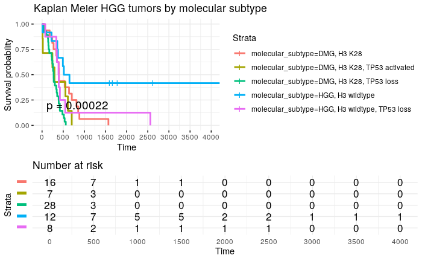

```r
surv_plot <- survminer::ggsurvplot(fit = kap_fit$model,
  data = kap_fit$original_data,
  pval = TRUE,
  risk.table = TRUE,
  xlim = c(0, 4000),
  break.time.by = 500,
  ggtheme = theme_minimal(),
  risk.table.y.text.col = TRUE,
  risk.table.y.text = FALSE,
)

surv_plot$plot <- surv_plot$plot +
  ggtitle(paste0("Kaplan Meier HGG tumors by molecular subtype")) +
  theme(legend.position = "right")

# Make this plot a combined plot
surv_plot_all_subtype <-
  cowplot::plot_grid(surv_plot[[1]], surv_plot[[2]], nrow = 2,
                     rel_heights = c(3, 2))

# Print it out here
surv_plot_all_subtype
```

Save the plot to a file.

```r
# We can save the plot like a normal ggplot
cowplot::save_plot(filename = kap_meier_plot_file, plot = surv_plot_all_subtype, base_height = 5, base_width = 8)
# Save the model itself as well as all other output from `survival_analysis()`
readr::write_rds(kap_fit, kap_meier_model_file)
```

## Analysis: cox regression for HGG molecular subtypes

We observe a significant poor prognostic effect of TP53 loss in tumors with H3 K28 mutations.

```r
# Run model
fit_save_model(metadata_ind_dna,
               "molecular_subtype",
               file.path(results_dir, "cox_hgg_subtype.RDS"))
```

```
Testing model: survival::Surv(OS_years, OS_status) ~ molecular_subtype with cox.reg
```

| term | estimate | std.error | statistic | p.value | conf.low | conf.high |
| --- | --- | --- | --- | --- | --- | --- |
| molecular_subtypeDMG, H3 K28, TP53 activated | 0.4221780 | 0.4607050 | 0.9163737 | 0.359470913 | -0.4807873 | 1.32514327 |
| molecular_subtypeDMG, H3 K28, TP53 loss | 0.9785591 | 0.3406201 | 2.8728755 | 0.004067543 | 0.3109560 | 1.64616222 |
| molecular_subtypeHGG, H3 wildtype | -0.9249790 | 0.4630234 | -1.9976941 | 0.045749830 | -1.8324881 | -0.01746994 |
| molecular_subtypeHGG, H3 wildtype, TP53 loss | 0.1570624 | 0.4439140 | 0.3538126 | 0.723479320 | -0.7129931 | 1.02711790 |

```r
# Double check the function isn't missing them - get the same result below
metadata_recode <- metadata_ind_dna %>%
      mutate(OS_status = ifelse(OS_status == "LIVING", 0, 1))
pairwise_survdiff(formula = Surv(OS_years, OS_status) ~ molecular_subtype,
                  data = metadata_recode)
```

```
    Pairwise comparisons using Log-Rank test

data:  metadata_recode and molecular_subtype

                            DMG, H3 K28 DMG, H3 K28, TP53 activated DMG, H3 K28, TP53 loss
DMG, H3 K28, TP53 activated 0.2020      -                           -
DMG, H3 K28, TP53 loss      0.0081      0.1369                      -
HGG, H3 wildtype            0.1335      0.1335                      0.0035
HGG, H3 wildtype, TP53 loss 0.9706      0.8754                      0.1335
                            HGG, H3 wildtype
DMG, H3 K28, TP53 activated -
DMG, H3 K28, TP53 loss      -
HGG, H3 wildtype            -
HGG, H3 wildtype, TP53 loss 0.1335

P value adjustment method: BH
```